# Police and Mass Shootings

Ella and MJ

12/12/2017

# Introduction

For this final project, we were interested in looking for a relationship between police shootings and mass shootings in the United States. It’s clear that gun violence is a prominent issue here, especially compared to other countries. The datasets we used comes from Stanford University and The Guardian. The counted dataset lists all the people who were killed by law enforcement agencies between 2015-2016. Variables within this dataset are primarily basic demographics (age, gender, race) on top of location, how they were killed, and whether they were armed or not. Our mass shootings of America (MSA) dataset is from Stanford University. The definition of mass shooting used for the database is 3 or more shooting victims (not necessarily fatalities), not including the shooter. The MSA dataset had over 30 variables that included demographics and information on the shooter as well as the victims. Our final project looked at different factors such as age, racial demographic, and media reports.

## Research Questions:

- How does the racial demographic of mass shooters compare to the racial demographic of the overall population in the states with the highest number of mass shootings per capita?
- Is there a difference in how the media reports on mass shootings committed by white people versus those committed by people of color?
- When adjusted to population, what states had the highest amount of police shootings?
- What are the demographics of minors who were killed by the police versus adults that were killed by the police?

# Methods

We did a lot of data manipulation before being able to approach our research questions. For the police shooting data sets, we needed to merge the different years. In order to adjust the number of shootings per state for population, we scraped state population data from the web. In addition, we found state demographic data that we downloaded and joined with our datasets to look at the demographics of shooters and victims compared to overall state demographics. In addition, the wordcloud involved doing a lot of pre-processing to put the motive description into a form feasible for wordcloud analysis.

## How does the racial demographic of mass shooters compare to the racial demographic of the overall population in the states with the highest number of mass shootings per capita?

First, we find the states with the highest number of shootings per capita.

The top three states with the most shootings per capita are:

```r
numshootings[1:3,]
```

```
##        State Shootings Population    Percapita
## 1 New Mexico         5    2081015 2.402674e-06
## 2    Alabama        11    4863300 2.261839e-06
## 3    Montana         2    1042520 1.918428e-06
```

We want to look at the demographics of the shooters in these states compared to the general population of these states.

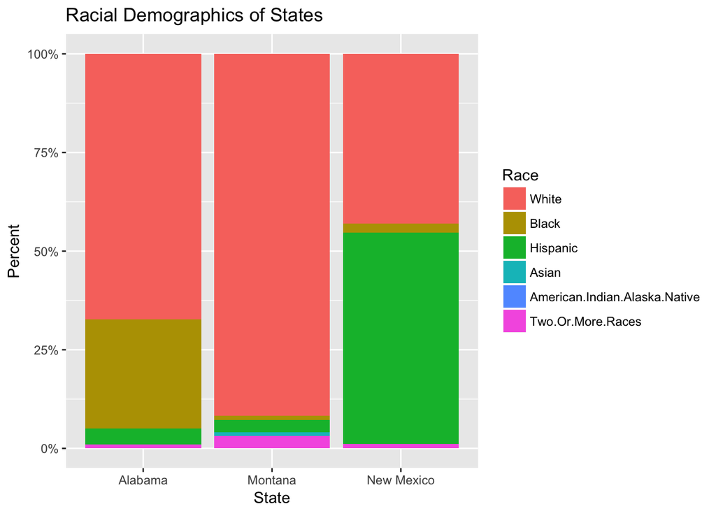

```r
ggplot(mgraphdata, aes(State, value, fill = variable)) +
    geom_bar(position = "fill", stat = "identity") +
    scale_y_continuous(labels = percent) + ggtitle("Racial Demographics of States") +
    xlab("State") + ylab("Percent") + scale_fill_discrete(name = "Race")
```

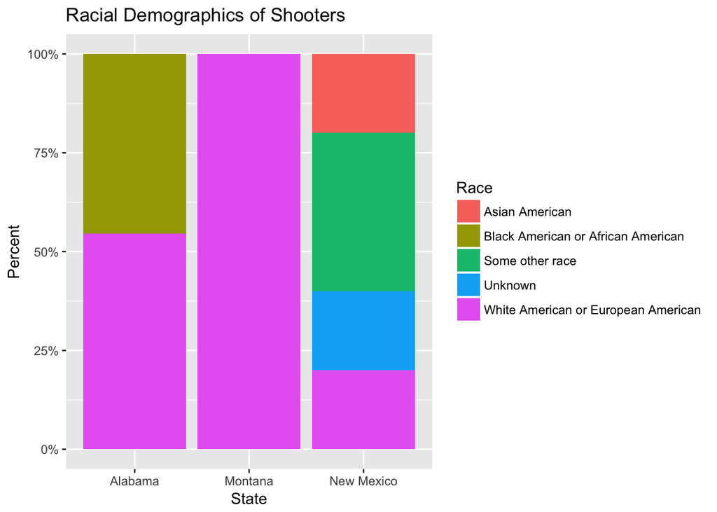

```r
ggplot(tops, aes(Var1, Freq, fill = Var2)) +
    geom_bar(position = "fill", stat = "identity") +
    scale_y_continuous(labels = percent) + xlab("State")+
    ylab("Percent") + ggtitle("Racial Demographics of Shooters") + scale_fill_discrete(name = "Race")
```

## Is there a difference in how the media reports on mass shootings committed by white people versus those committed by people of color?

The stanford dataset had a variable that contained a detailed description of the possible motive of the shooter as described by media sources. We create a wordcloud to look at the most-used words in these descriptions.

## White Shooters:

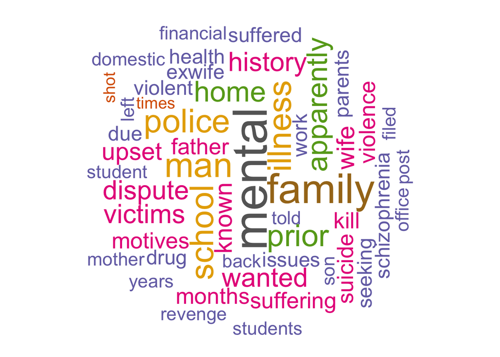

```r
wordcloud(words = d1$word, freq = d1$freq, min.freq = 2,
          max.words=50, random.order=FALSE, rot.per=0.35,
          colors=brewer.pal(8, "Dark2"))
```

## POC Shooters:

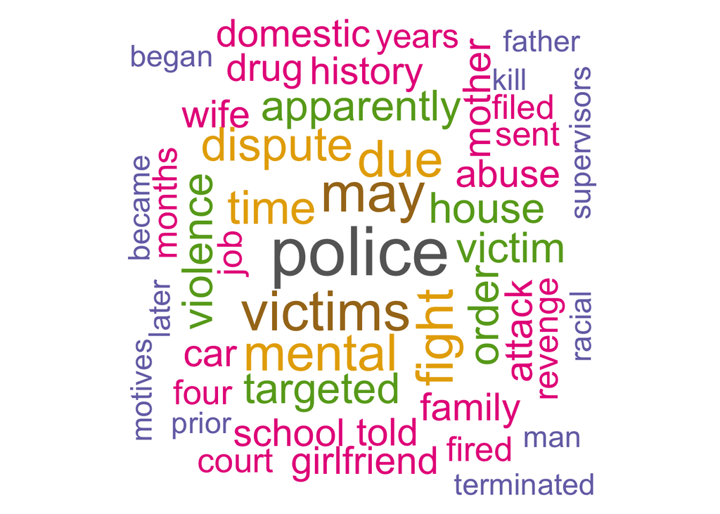

```r
wordcloud(words = d$word, freq = d$freq, min.freq = 2,
          max.words=50, random.order=FALSE, rot.per=0.35,
          colors=brewer.pal(8, "Dark2"))
```

## When adjusted to population, what states had the highest amount of police shootings?

```r
# City shootings
city.shootings <- leaflet(city.colors) %>%
  addTiles() %>%
  addCircleMarkers(
    lng = ~lng,
    lat = ~lat,
    label = city.colors$type,
    color = city.colors$color,
    stroke = FALSE,
    fillOpacity = 1,
    clusterOptions = markerClusterOptions()
  )
city.shootings
```

[interactive chart not shown]

## What are the demographics of minors who were killed by the police versus adults that were killed by the police?

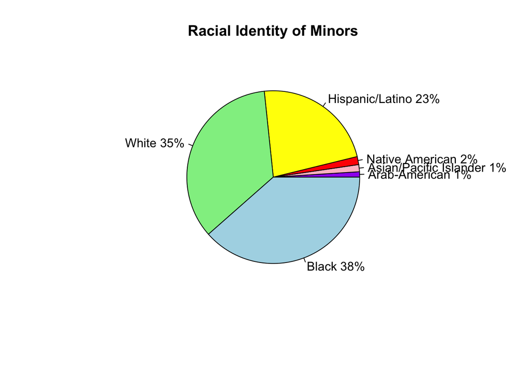

```r
minors <- pie(minors.race$Freq , labels = lbl,
              main = "Racial Identity of Minors",
              col = c("purple", "pink", "red", "yellow", "light green", "light blue"))
```

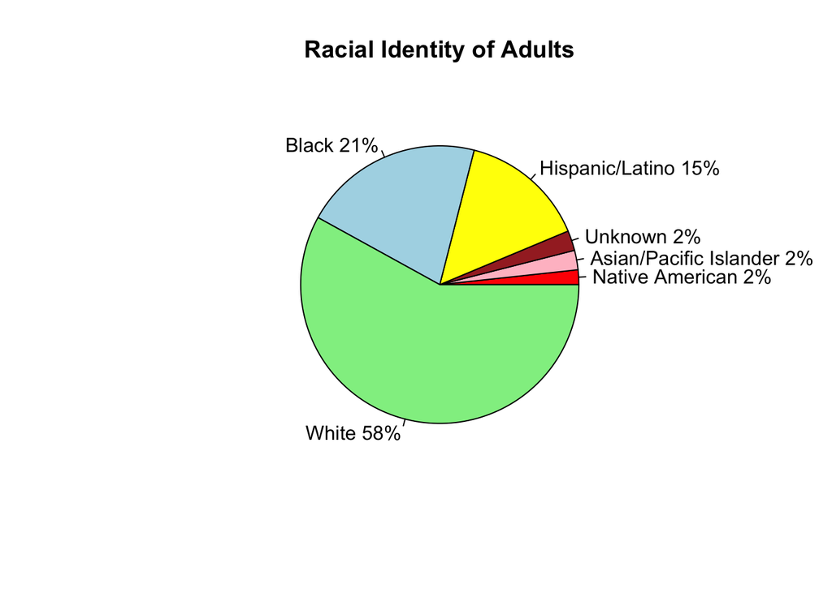

```r
adults <- pie(adults.race$Freq, labels = lbl.a, main = "Racial Identity of Adults",
              col = c("red", "pink", "brown", "yellow", "light blue", "light green"))
```

## Results and Conclusion

- How does the racial demographic of mass shooters compare to the racial demographic of the overall population in the states with the highest number of mass shootings per capita? The top 3 states for mass shootings (when adjusted to the population) were New Mexico, Alabama, and Montana. When comparing the racial demographics, we found that it was similar between the shooter and the state as a whole.
- Is there a difference in how the media reports on mass shootings committed by white people versus those committed by people of color? To answer this question, we made 2 different word maps in order to see the difference between how the media portrayed the motivations of white people in contrast to black people. The most common word used for white shooters was “mental illness”, while the most common word for black people was “police.”
- When adjusted to population, what states had the highest amount of police shootings? First, we created a leaflet map that showed the amount of police caused killings for every state in order to see the differences. It was clear that the cities with 30-40 killings were major metropolitan areas (Los Angeles, Houston, DC, etc). However, when the population was adjusted, the top cities were New Mexico, Alaska and Oklahoma.
- Is there a difference between the racial demographics of minors versus the racial demographics of adults? Yes, with adults it was 58% white people and 21% black people. When we look at minors, we see that the amount of white people decreases to 35% and the amount of black people increases to 38%. In looking at the overall percentages, 73% of the police shootings were adults and 27% were minors.

Of our findings, an interesting finding was how New Mexico was the top state for both mass shootings and police shootings. We can conclude that New Mexico has a gun violence issue, but this also goes for other areas. The total number of reported police shootings was 2,236 in only 2 years (2015-2016) and the number of mass shootings was 349. Within those mass shootings, the total number of fatalities were 1,237. Some suggestions for potential solutions are for law enforcement agencies to hold more accountability over their officers and reform gun control laws. Additionally, our results that look at racial demographics show how racial profiling still exists, especially towards black people. The word maps we created shows how the media also feeds into this by portraying them differently based on their racial identity.

Lastly, we’d like to give credit for the people who organized the datasets. For the Stanford Mass Shootings in America, courtesy to the Stanford Geospatial Center and Stanford Libraries. The other dataset is from The Guardian, who created this dataset for their project The Counted with the purpose of releasing information on police shootings that agencies don’t share.

https://library.stanford.edu/projects/mass-shootings-america https://www.theguardian.com/thecounted https://simplemaps.com/data/us-cities http://www.fonz.net/blog/archives/2008/04/06/csv-of-states-and-state-abbreviations/